# Lab 05 - Halloween Candies & Data Viz Improvement

Lizzy

2026-10-30

### Load packages

```r
library(tidyverse)
library(ggplot2)
```

# Questioning data visualisations

## Image 1

*Volumes of rectangles are not proportional to the data its showing, the varying colours do not seem to represent any data so just seem confusing. you could create this with a bar or col graph.*

## Image 2

*There are no numerical values to show if the proportions seem correct and the colouring seems off as the shade of each sector seems to be assigned at random rather than highlighting the smallest vs largest proportions etc…*

## Image 3

*The scatter graph seems messy as the plots overlap and yet each point contains data. It seems like each point has varying colour and size which may have some meaning, but there is no key to demonstrate this, also the axes have no values to actually read the data.*

## Image 4

*Clearly identifies each country and colour codes each are/slope for each, seems very clear.*

# Data Visualization for Halloween

Ensure that you have the following two lines of code at the top of `lab-05.Rmd` to make the commands available to you.

```r
library(tidyverse)
library(ggplot2)

# Install that package first
# install.packages("fivethirtyeight")
library(fivethirtyeight)
```

```r
candy_df <- candy_rankings
glimpse(candy_df)
```

```
## Rows: 85
## Columns: 13
## $ competitorname   <chr> "100 Grand", "3 Musketeers", "One dime", "One quarter…
## $ chocolate        <lgl> TRUE, TRUE, FALSE, FALSE, FALSE, TRUE, TRUE, FALSE, F…
## $ fruity           <lgl> FALSE, FALSE, FALSE, FALSE, TRUE, FALSE, FALSE, FALSE…
## $ caramel          <lgl> TRUE, FALSE, FALSE, FALSE, FALSE, FALSE, TRUE, FALSE,…
## $ peanutyalmondy   <lgl> FALSE, FALSE, FALSE, FALSE, FALSE, TRUE, TRUE, TRUE, …
## $ nougat           <lgl> FALSE, TRUE, FALSE, FALSE, FALSE, FALSE, TRUE, FALSE,…
## $ crispedricewafer <lgl> TRUE, FALSE, FALSE, FALSE, FALSE, FALSE, FALSE, FALSE…
## $ hard             <lgl> FALSE, FALSE, FALSE, FALSE, FALSE, FALSE, FALSE, FALS…
## $ bar              <lgl> TRUE, TRUE, FALSE, FALSE, FALSE, TRUE, TRUE, FALSE, F…
## $ pluribus         <lgl> FALSE, FALSE, FALSE, FALSE, FALSE, FALSE, FALSE, TRUE…
## $ sugarpercent     <dbl> 0.732, 0.604, 0.011, 0.011, 0.906, 0.465, 0.604, 0.31…
## $ pricepercent     <dbl> 0.860, 0.511, 0.116, 0.511, 0.511, 0.767, 0.767, 0.51…
## $ winpercent       <dbl> 66.97173, 67.60294, 32.26109, 46.11650, 52.34146, 50.…
```

## Exercise 1

How many observations and variables are in this dataset? Did you identify the type of variables, remember that this detail is crucial to create which kind of data visualization in general.

*There are 13 variables and 85 observations, the data types included are double, logical and character.*

# Data viz - One variable at a time

Just to use the logical variables as categories, run the following code chunk first!

```r
candy_df <- candy_df %>%
  mutate(across(where(is.logical), as_factor))
```

## Exercise 2

Complete the following code to get the data viz to represent “how many candies contain caramel via bar plot”. Fill in the blanks, remove the # symbol in front of your code and the execute the code chunk via green play button.

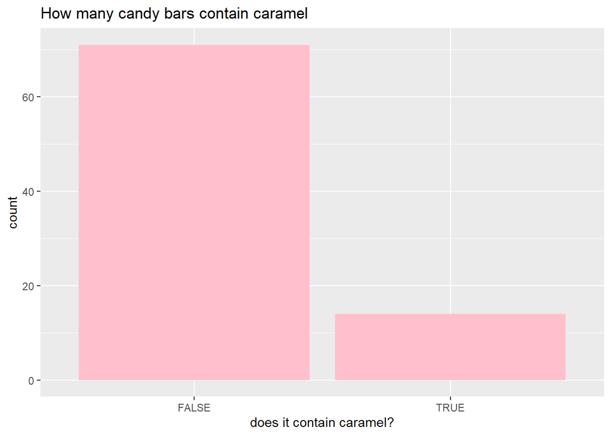

```r
 ggplot(candy_rankings, aes(x = caramel)) +
 geom_bar(fill = "pink") +
  labs(
    title = "How many candy bars contain caramel",
    x = "does it contain caramel?"
  )
```

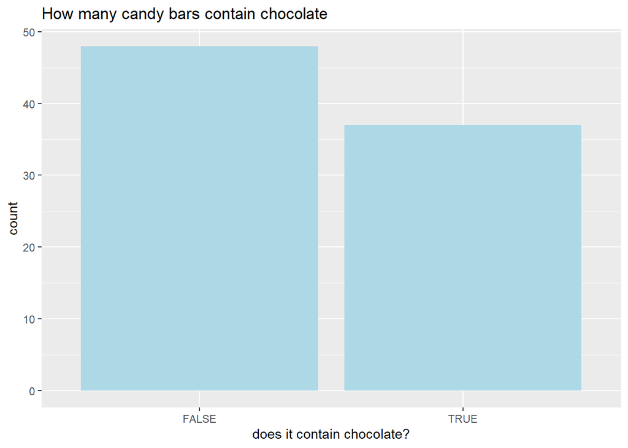

```r
ggplot(candy_rankings, aes(x = chocolate)) +
 geom_bar(fill = "lightblue") +
  labs(
    title = "How many candy bars contain chocolate",
    x = "does it contain chocolate?"
  )
```

## Exercise 3

Now look at a numerical variable, such as `winpercent`. Create an histogram for this variable using ggplot2 functions below. Include informative x and y labels and a title, as a good practice.

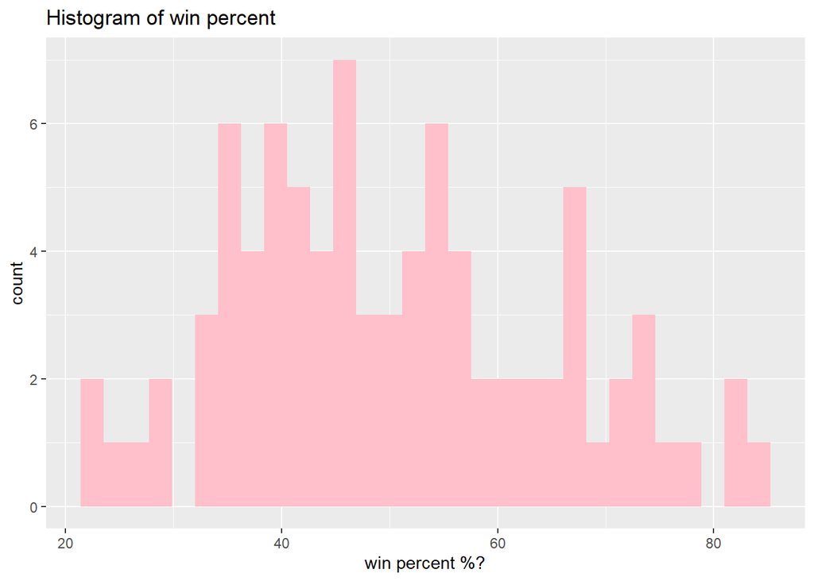

```r
 ggplot(candy_rankings, aes(x = winpercent)) +
 geom_histogram(fill = "pink") +
  labs(
    title = "Histogram of win percent",
    x = "win percent %?"
  )
```

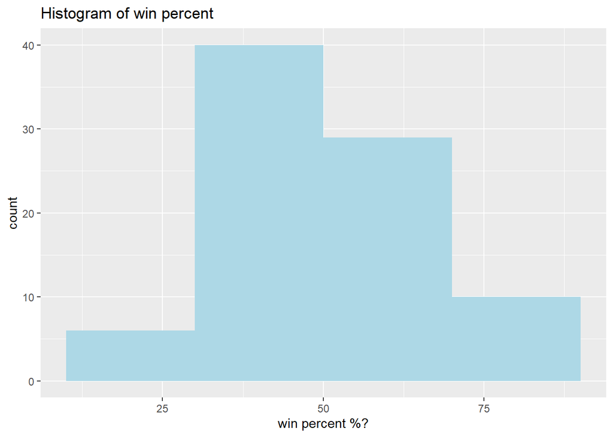

```r
 ggplot(candy_rankings, aes(x = winpercent)) +
 geom_histogram(fill = "lightblue", binwidth = 20) +
  labs(
    title = "Histogram of win percent",
    x = "win percent %?"
  )
```

# Data viz - more than one variable

## Exercise 4

How about using the both variables; chocolate vs winpercent? Run the following incomplete code snippet to get a faceted visualization.

Fill in the blanks, remove the # symbol in front of your code and the execute the code chunk via green play button.

```
## Ignoring unknown labels:
## • colour : "Does it contain caramel?"
```

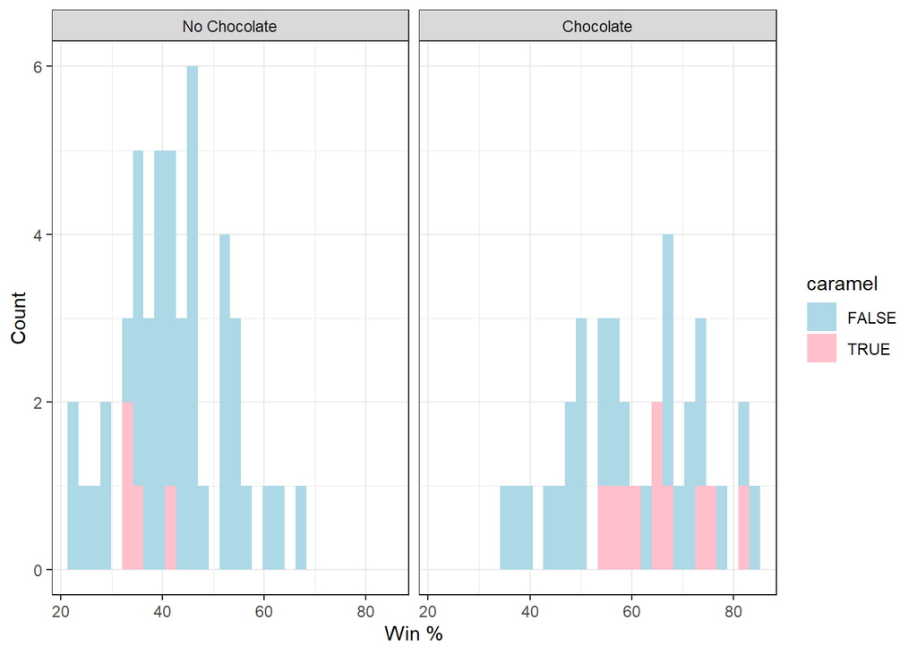

```r
ggplot(candy_df, aes(x = winpercent, fill = caramel)) +
  geom_histogram() +
  facet_wrap(~chocolate,labeller = as_labeller(c(
    "TRUE" = "Chocolate",
    "FALSE" = "No Chocolate"))) +
  theme_bw() +
  labs(
    colour = "Does it contain caramel?",
    x = "Win %",
    y = "Count"
  ) +
  scale_fill_manual(values = c(
  "TRUE" = "pink",
  "FALSE" = "lightblue"
))
```

- Consider adding the `fill = caramel` within the aes() vs. geom_histogram(), what do you get?

## Exercise 5

Create a visualization that examines the relationship between a candy’s win percentage and whether it contains chocolate. Include x and y labels and a title. Describe any relationship you see.

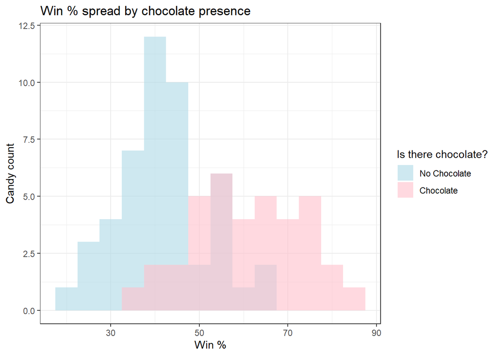

```r
die = candy_df %>% filter(!is.na(chocolate))

ggplot(die, aes(x = winpercent, fill = chocolate)) +
  geom_histogram(binwidth = 5, position = "identity", alpha = 0.6) +
  scale_fill_manual(values = c("TRUE" = "pink", "FALSE" = "lightblue"),
                    labels = c("TRUE" = "Chocolate", "FALSE" = "No Chocolate")) +
  theme_bw() +
  labs(
    title = "Win % spread by chocolate presence",
    x = "Win %",
    y = "Candy count",
    fill = "Is there chocolate?"
  )
```

[figure not shown]

```r
ggplot(die, aes(x = winpercent, fill = fruity)) +
  geom_histogram(binwidth = 5, position = "identity", alpha = 0.6) +
  scale_fill_manual(values = c("TRUE" = "pink", "FALSE" = "lightblue"),
                    labels = c("TRUE" = "Yes", "FALSE" = "No")) +
  theme_bw() +
  labs(
    title = "Win % spread by --- presence",
    x = "Win %",
    y = "Candy count",
    fill = "Is there ---?"
  )
```

- Consider the similar pair by replacing chocolate with caramel, fruity and compare their results.
- Also include summary statistics details for this discussion by using the calculation below:

```r
candy_rankings %>%
  group_by(chocolate) %>%
  summarise(
    n = n(),
    mean_win = mean(winpercent),
    median_win = median(winpercent)
  )
```

```
## # A tibble: 2 × 4
##   chocolate     n mean_win median_win
##   <lgl>     <int>    <dbl>      <dbl>
## 1 FALSE        48     42.1       41.6
## 2 TRUE         37     60.9       60.8
```

## Exercise 6

Do more expensive candies win more often? Make a scatterplot of pricepercent (x) against winpercent (y). Describe their relationship.

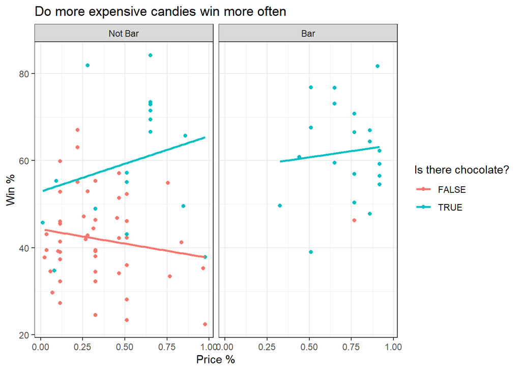

```r
ggplot(die, aes(x = pricepercent, y = winpercent, colour = chocolate)) +
  geom_point() +
  facet_wrap(~bar, labeller = as_labeller(c(
    "TRUE" = "Bar",
    "FALSE" = "Not Bar"))) +
  scale_fill_manual(values = c("TRUE" = "pink", "FALSE" = "lightblue"),
                    labels = c("TRUE" = "Yes", "FALSE" = "No")) +
  theme_bw() +
  labs(
    title = "Do more expensive candies win more often",
    y = "Win %",
    x = "Price %",
    colour = "Is there chocolate?"
  ) +
  geom_smooth(method = lm, se = FALSE)
```

- Add `color = chocolate` to add a third variable to the created visualization
- How to facet this by using another categorical variable such as `bar`?

## Exercise 7

Are chocolate candies more likely to be candy bars? Make a filled bar plot with chocolate on the x-axis and fill = bar. Describe what you see.

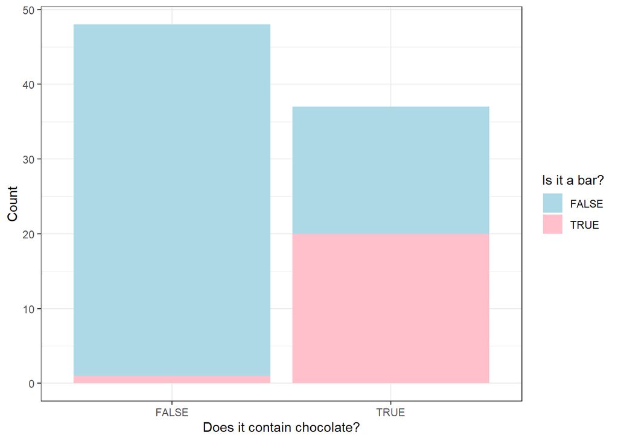

```r
ggplot(candy_df, aes(x = chocolate, fill = bar)) +
  geom_bar() +
  theme_bw() +
  labs(
    fill = "Is it a bar?",
    x = "Does it contain chocolate?",
    y = "Count"
  ) +
  scale_fill_manual(values = c(
  "TRUE" = "pink",
  "FALSE" = "lightblue"
))
```

## Exercise 8

Create a new variable called price per sugar ratio as the division of pricepercent and sugarpercent. Plot it against winpercent, and set the color of all points to blue for the competitors who are not “One dime” or “One quarter”. Include x and y labels and a title. Describe any relationship you see.

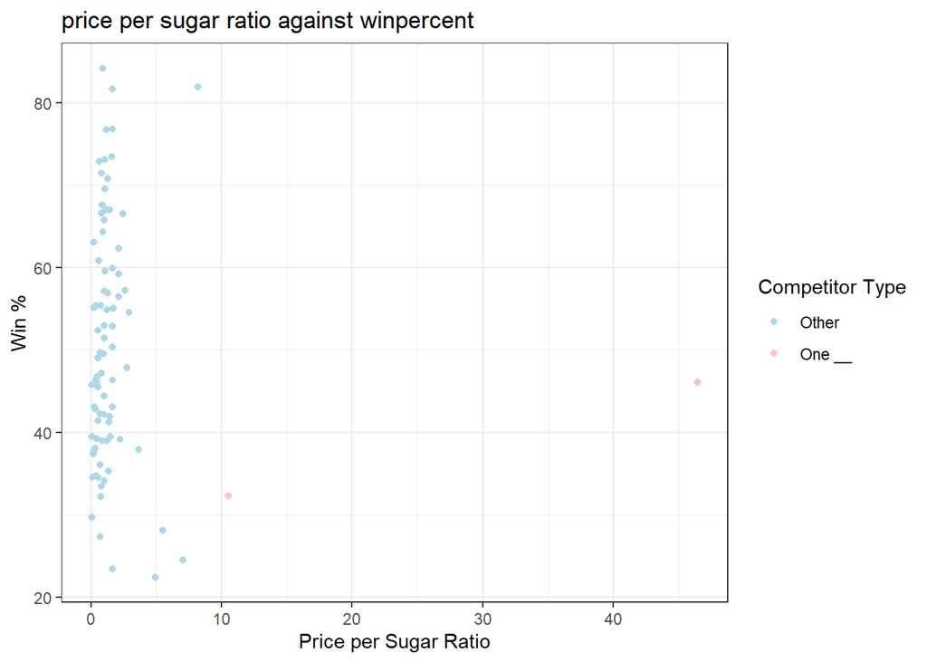

```r
df1 = candy_df %>%
  mutate(ppsr = pricepercent/sugarpercent,
         type = case_when(
           competitorname == "One quarter" ~ TRUE,
           competitorname == "One dime" ~ TRUE,
           TRUE ~ FALSE
         ))

ggplot(df1, aes(x = ppsr, y = winpercent, colour = type)) +
  geom_point() +
  scale_colour_manual(values = c("TRUE" = "pink", "FALSE" = "lightblue"),
                    labels = c("TRUE" = "One __", "FALSE" = "Other")) +
  theme_bw() +
  labs(
    title = "price per sugar ratio against winpercent",
    y = "Win %",
    x = "Price per Sugar Ratio",
    colour = "Competitor Type"
  )
```

```r
  #geom_smooth(method = lm, se = FALSE)
```

## Exercise 9

Modify your plot in Exercise 8 to facet by whether a candy is bar-shaped. Have the color reflect whether the candy is fruity or not. The plot must include x and y labels along with a title. How do these plots compare to each other?

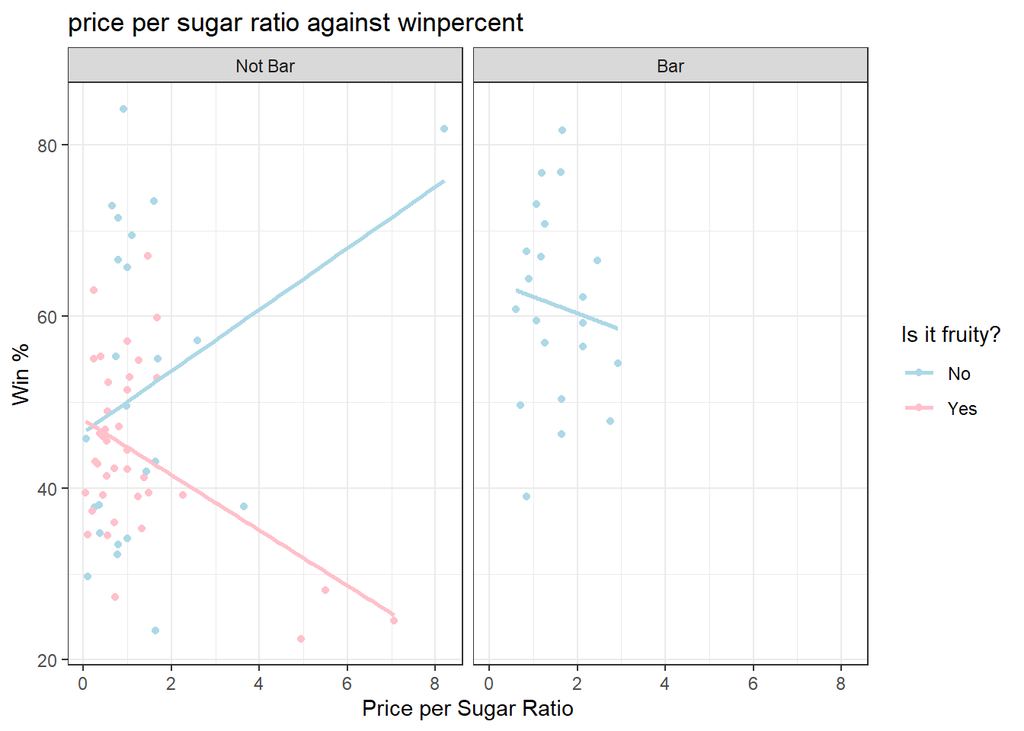

```r
df1 = candy_df %>%
  mutate(ppsr = pricepercent/sugarpercent,
         type = case_when(
           competitorname == "One quarter" ~ TRUE,
           competitorname == "One dime" ~ TRUE,
           TRUE ~ FALSE
         )) %>%
  filter(type == FALSE)

ggplot(df1, aes(x = ppsr, y = winpercent, colour = fruity)) +
  geom_point() +
  scale_colour_manual(values = c("TRUE" = "pink", "FALSE" = "lightblue"),
                    labels = c("TRUE" = "Yes", "FALSE" = "No")) +
  theme_bw() +
  labs(
    title = "price per sugar ratio against winpercent",
    y = "Win %",
    x = "Price per Sugar Ratio",
    colour = "Is it fruity?"
  ) +
  facet_wrap(~bar, labeller = as_labeller(c(
    "TRUE" = "Bar",
    "FALSE" = "Not Bar"))) +
  geom_smooth(method = lm, se = FALSE)
```

# Take a sad plot and make it better!

```r
staff <- read_csv("data/instructional-staff.csv")
```

## Exercise 1

What is the difference between *wide format* data and *long format* data?

Is the format `staff` data *wide* or *long*? - wide

## Exercise 2

```r
staff_long <- staff %>%
  pivot_longer(
    cols = c(`1975`, `1989`, `1993`,`1995`, `1999`, `2001`,
             `2003`, `2005`, `2007`, `2009`, `2011`),
    names_to = "years",
    values_to = "percent"
  )
```

## Exercise 3

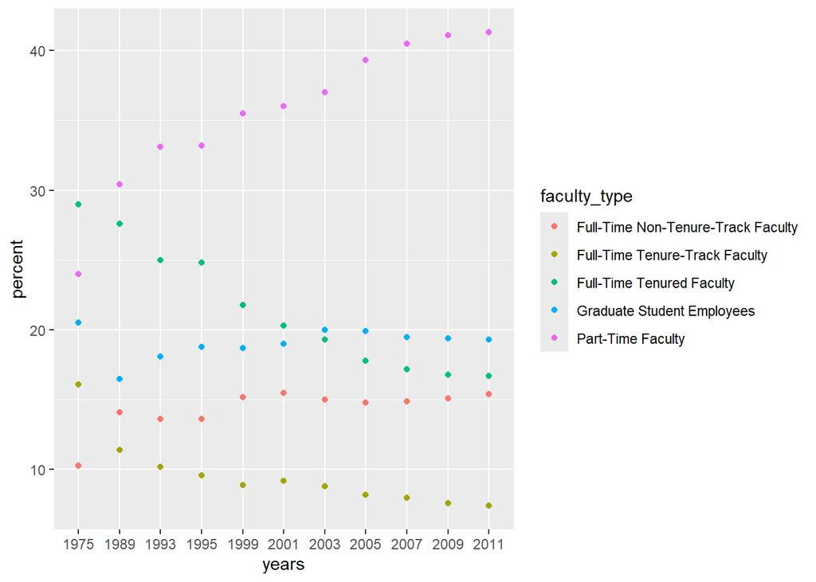

```r
# Write your code for Exercise 3 here

ggplot(data= staff_long, mapping = aes(x = years, y = percent, colour = faculty_type)) +
  geom_point()
```

## Exercise 4

```
## `geom_line()`: Each group consists of only one observation.
## ℹ Do you need to adjust the group aesthetic?
```

[figure not shown]

```r
ggplot(data= staff_long, mapping = aes(x = years, y = percent, colour = faculty_type)) +
  geom_line()
```

## Exercise 5

```r
staff_long <- staff_long %>%
  mutate(years = as.numeric(years))
```

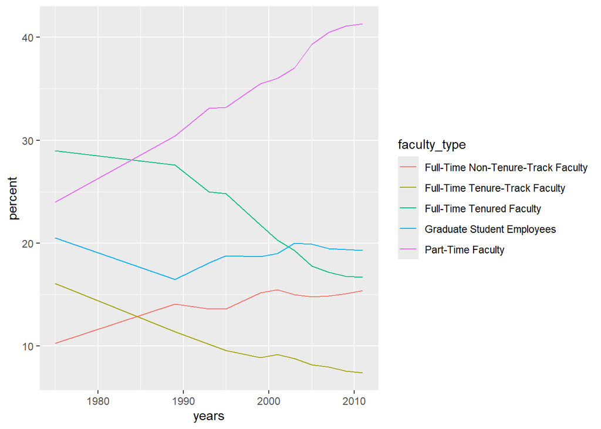

```r
# Write your code for Exercise 5 here

ggplot(data= staff_long, mapping = aes(x = years, y = percent, colour = faculty_type)) +
  geom_line()
```

## Exercise 6

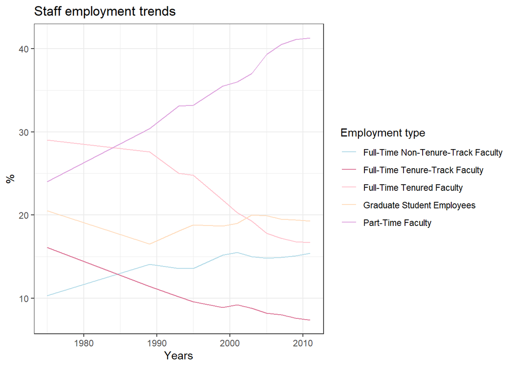

```r
# Write your code for Exercise 6 here


ggplot(data= staff_long, mapping = aes(x = years, y = percent, colour = faculty_type)) +
  geom_line() +
  scale_colour_manual(values = c("Full-Time Tenured Faculty" = "pink", "Full-Time Tenure-Track Faculty" = "palevioletred", "Full-Time Non-Tenure-Track Faculty" = "lightblue", "Part-Time Faculty" = "plum", "Graduate Student Employees" = "peachpuff")) +
  theme_bw() +
  labs(
    title = "Staff employment trends",
    y = "%",
    x = "Years",
    colour = "Employment type"
  )
```

## Exercise 7

*Write below your ideas for adapting the line plot*

```r
# Write your code for Exercise 7 here, based on one of your ideas
```